# Exploratory Analysis

## Four assumptions associated with a linear regression:

1.Linearity: The relationship between X and the mean of Y is linear.

2.Homoscedasticity: The variance of residual is the same for any value of X. We can test this assumption later, after fitting the linear model.

3.Independence: Observations are independent of each other.

4.Normality: For any fixed value of X, Y is normally distributed.

# Data import and clean

```r
data_df=read.csv("./data/cdi.csv") %>%
  mutate(CRM_1000=crimes/pop*1000) %>%  ## add new variable CRM_1000(the crime rate per 1,000 population)
  dplyr::select(-crimes) %>%
  dplyr::select(-id,-cty,-state) %>%
  mutate(region=as.factor(region))
```

## TWO tables of 14 variables

```r
numeric_variable_tb=tibble(Variable=c("area","pop","pop18","pop65","docs","beds","hsgrad","bagrad","poverty","unemp","pcincome","totalinc","CRM_1000"),
                   mean=c(1041,393011,28.6,12.2,988,1459,77.6,21.1,8.72,6.60,18561,7869,57.3),
                   sd=c(1550,601987,4.19,3.99,1790,2289,7.02,7.65,4.66,2.34,4059,12884,27.3)) %>%knitr::kable(digit=2,caption="A Table for Numeric Variables")

factor_variable_tb=tibble(region=c("1 ( Northeast )","2 ( North central )","3 ( South )","4 ( West )"),
                          Frequency=c(103,108,152,77)) %>% knitr::kable(caption="A Frequency Table")





numeric_variable_tb
```

A Table for Numeric Variables

| Variable | mean | sd |
| --- | --- | --- |
| area | 1041.00 | 1550.00 |
| pop | 393011.00 | 601987.00 |
| pop18 | 28.60 | 4.19 |
| pop65 | 12.20 | 3.99 |
| docs | 988.00 | 1790.00 |
| beds | 1459.00 | 2289.00 |
| hsgrad | 77.60 | 7.02 |
| bagrad | 21.10 | 7.65 |
| poverty | 8.72 | 4.66 |
| unemp | 6.60 | 2.34 |
| pcincome | 18561.00 | 4059.00 |
| totalinc | 7869.00 | 12884.00 |
| CRM_1000 | 57.30 | 27.30 |

```r
factor_variable_tb
```

A Frequency Table

| region | Frequency |
| --- | --- |
| 1 ( Northeast ) | 103 |
| 2 ( North central ) | 108 |
| 3 ( South ) | 152 |
| 4 ( West ) | 77 |

```r
## describe(data_df)
```

## distribution of target variable and log transformation for target variable.AT last,we generate a new variable log_CRM_1000 which is approximated to normal distribution

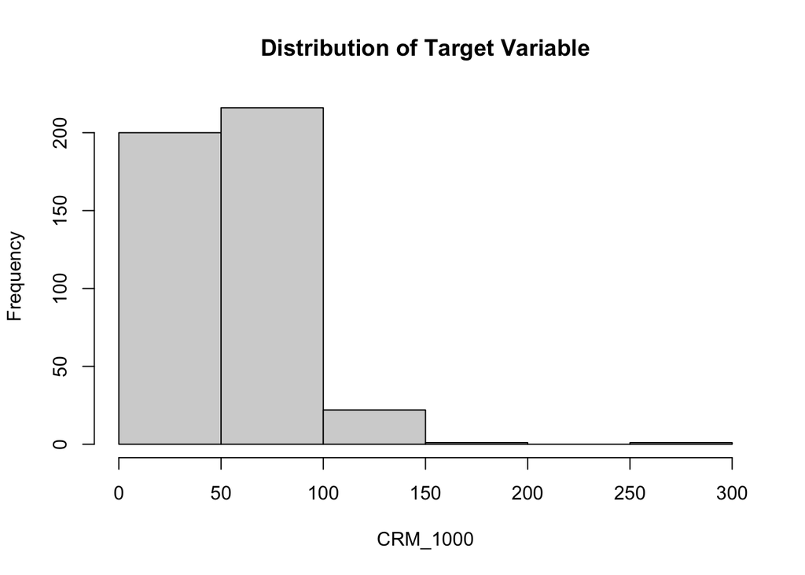

```r
hist(data_df$CRM_1000,xlab="CRM_1000",main="Distribution of Target Variable")  ## right-skewed so we use log transformation for target variable
```

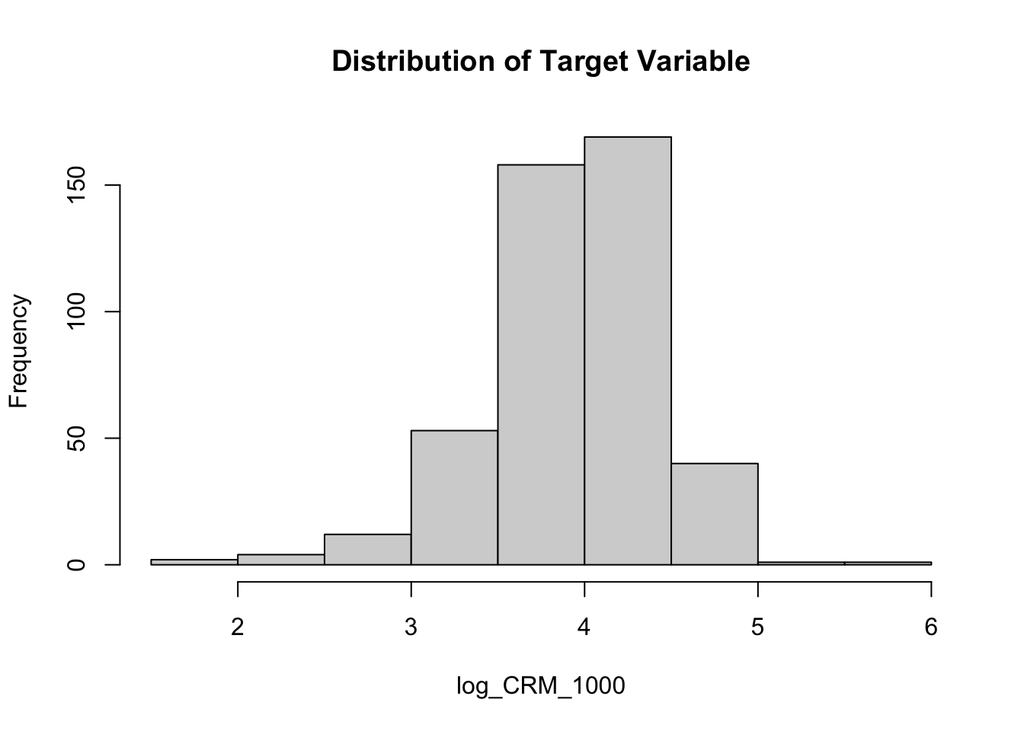

```r
data_df=data_df %>%
  mutate(log_CRM_1000=log(CRM_1000)) %>%
  dplyr::select(-CRM_1000)
hist(data_df$log_CRM_1000,,xlab="log_CRM_1000",main="Distribution of Target Variable")## bell-sharped so log transformation for target variable is perfect
```

## Checking outliers using boxplots

boxplot for each continuous variable

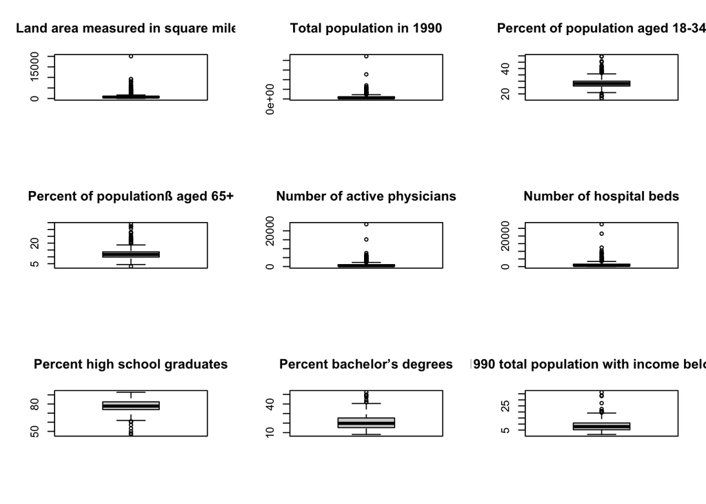

```r
par(mfrow=c(3,3))
boxplot(data_df$area,main='Land area measured in square miles')

boxplot(data_df$pop,main='Total population in 1990')

boxplot(data_df$pop18,main='Percent of population aged 18-34')

boxplot(data_df$pop65,main='Percent of populationß aged 65+')

boxplot(data_df$docs,main='Number of active physicians')

boxplot(data_df$beds,main='Number of hospital beds')


boxplot(data_df$hsgrad,main='Percent high school graduates')

boxplot(data_df$bagrad,main='Percent bachelor’s degrees')

boxplot(data_df$poverty,main='Percent of 1990 total population with income below poverty level')
```

[figure not shown]

```r
par(mfrow=c(2,2))
boxplot(data_df$unemp,main='Percent below poverty level')

boxplot(data_df$pcincome,main='Per capita income')

boxplot(data_df$totalinc,main='Total personal income')

boxplot(data_df$log_CRM_1000,main='Log of the crime rate per 1,000 population')
```

## histogram(distribution of 12 independent numeric variables)

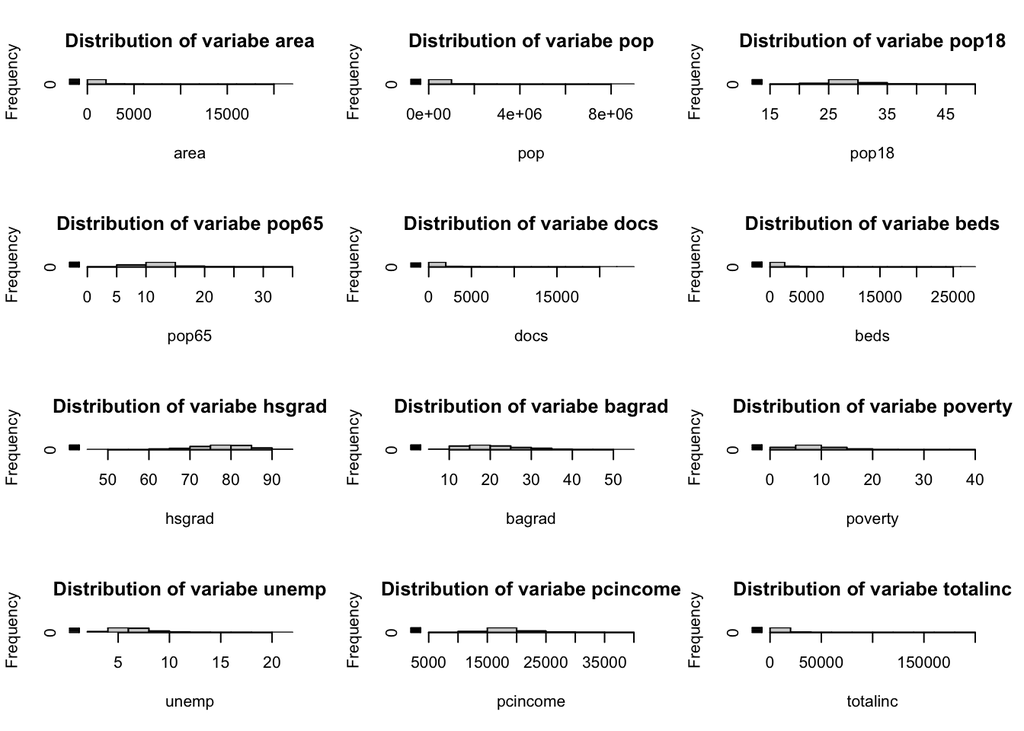

```r
data_without_region_df=
  data_df %>% dplyr::select(-region,-log_CRM_1000) ## since histogram cannot be plotted using a factor variable, we delete the variable region.

par(mfrow=c(4,3))

for (n in 1:ncol(data_without_region_df)){
  var = names(data_without_region_df)[n]
  hist(data_without_region_df[,n],xlab = var,main=str_c("Distribution of"," variabe ",var))
}
```

from 12 histograms of each numeric variable, we notice the distribution of 5 histograms are right-skewed, therefore, we need to perform log transformation for these five variables(area,pop,docs,beds and totalinc)

## log transformation for five variables whose distribution is right-skewed

```r
data_df = data_df %>%
  mutate(log_area = log(area),
         log_pop = log(pop),
         log_docs = log(docs),
         log_beds = log(beds),
         log_totalinc = log(totalinc)
         ) %>%
  dplyr::select(-pop,-area,-docs,-beds,-totalinc)
```

## Re-check distribution of independent variables

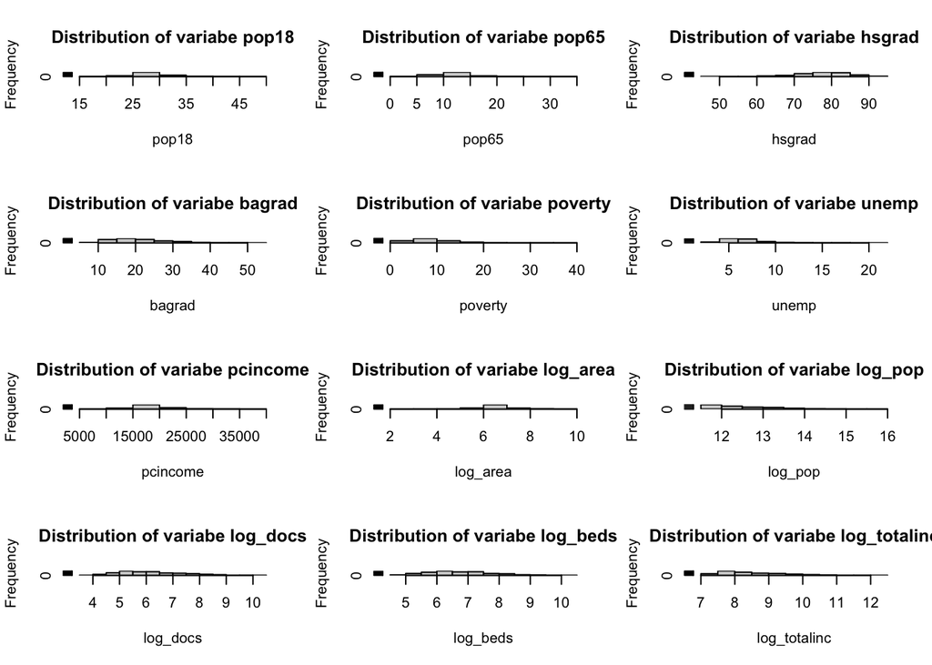

```r
data_without_region_log_CRM1000_df=
  data_df %>% dplyr::select(-region,-log_CRM_1000)

## histogram after transformation
par(mfrow=c(4,3))
for (n in 1:ncol(data_without_region_log_CRM1000_df)){
  var = names(data_without_region_log_CRM1000_df[n])
  hist(data_without_region_log_CRM1000_df[,n],xlab = var,main=str_c("Distribution of"," variabe ",var))
}
```

After log transformation, in histograms, we notices except for the variable log_pop, right-skewed problems of four variables mentioned before has been solved.

## relationship of two variables(pairs)

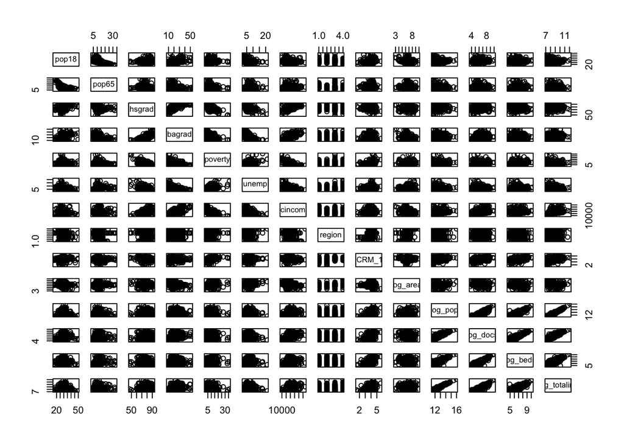

```r
pair_df=
  data_df

pairs(data_df)
```

As shown in scatter plots,we can find it seems there is a linear relationship between any two of log_pop,log_docs,log_beds and log_totalinc

## Correlation plot

In theory,the correlation between independent variables should be zero.In particular,we expect and are okey with weak to no correlation between independent variables. We also expect that independent variables reflect a high correlation with the target variable.

[figure not shown]

```r
cor_df=
  data_df %>%
  dplyr::select(-region) %>%
  cor() ## Correlation coefficient

require(corrgram)
corrgram(data_df, order=TRUE)
```

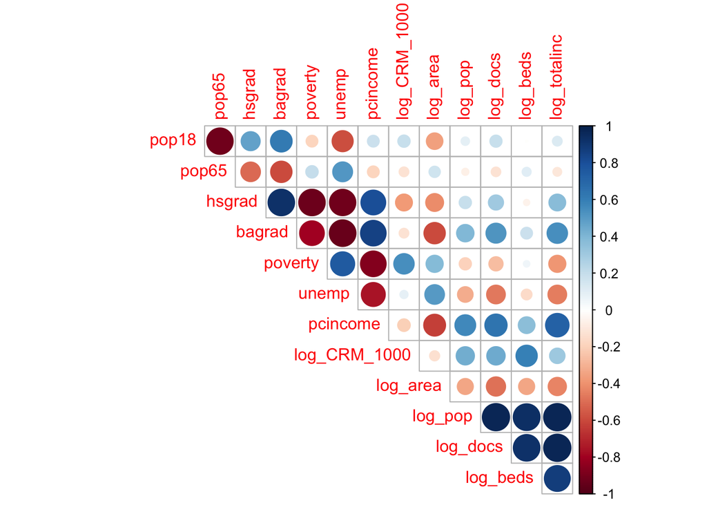

```r
corrplot(cor(cor_df), type = "upper", diag = FALSE)
```

from the correlaton plot,we can find independent variables like poverty(0.423),log_docs(0.423),log_beds(0.464) have a high correlation with the target variable log_CRM_1000. In addition,we also notice independent variables like log_totalinc,log_beds,log_docs and log_pop have a high correlation with each other.